# Regressão - Aplicações em Dados Financeiros

# Calculando da Carteira

Para a construção da Carteira iremos aplicar a seguinte fórmula:

$$\mathbb{E}(R_{pt}) = \sum^{n}_{i=1}
\sum^{T}_{t=1} w_{i} \mathbb{E}(R_{it})$$

Para isso vamos usar o *dataframe* chamado *returns_melt*.

```r
pesos = c(0.15, 0.15, 0.15, 0.15, 0.4, 0)
pesos
```

```
## [1] 0.15 0.15 0.15 0.15 0.40 0.00
```

```r
sum(pesos)
```

```
## [1] 1
```

```r
wts_tbl <- tibble(acoes = acoes,
                  wts = pesos)
head(wts_tbl)
```

```
## # A tibble: 6 x 2
##   acoes      wts
##   <chr>    <dbl>
## 1 BBAS3.SA  0.15
## 2 BRFS3.SA  0.15
## 3 CIEL3.SA  0.15
## 4 PETR3.SA  0.15
## 5 MGLU3.SA  0.4
## 6 ^BVSP     0
```

```r
returns_port = left_join(returns_melt,wts_tbl, by = 'acoes')
head(returns_port)
```

```
##         date    acoes     retornos  wts
## 1 2015-01-02 BBAS3.SA  0.000000000 0.15
## 2 2015-01-05 BBAS3.SA -0.020968870 0.15
## 3 2015-01-06 BBAS3.SA  0.013879784 0.15
## 4 2015-01-07 BBAS3.SA  0.043078229 0.15
## 5 2015-01-08 BBAS3.SA  0.003401321 0.15
## 6 2015-01-09 BBAS3.SA -0.044258763 0.15
```

```r
returns_port %>%
  group_by(acoes) %>%
  slice(c(1,2))
```

```
## # A tibble: 12 x 4
## # Groups:   acoes [6]
##    date       acoes    retornos   wts
##    <date>     <chr>       <dbl> <dbl>
##  1 2015-01-02 ^BVSP      0       0
##  2 2015-01-05 ^BVSP     -0.0207  0
##  3 2015-01-02 BBAS3.SA   0       0.15
##  4 2015-01-05 BBAS3.SA  -0.0210  0.15
##  5 2015-01-02 BRFS3.SA   0       0.15
##  6 2015-01-05 BRFS3.SA  -0.0192  0.15
##  7 2015-01-02 CIEL3.SA   0       0.15
##  8 2015-01-05 CIEL3.SA  -0.0346  0.15
##  9 2015-01-02 MGLU3.SA   0       0.4
## 10 2015-01-05 MGLU3.SA   0.0186  0.4
## 11 2015-01-02 PETR3.SA   0       0.15
## 12 2015-01-05 PETR3.SA  -0.0846  0.15
```

```r
returns_port <- returns_port %>%
  mutate(wt_retornos = wts * retornos)
```

Vamos agora dar uma olhada na nova variável criada

```r
returns_port %>%
  group_by(acoes) %>%
  slice(c(1,2))
```

```
## # A tibble: 12 x 5
## # Groups:   acoes [6]
##    date       acoes    retornos   wts wt_retornos
##    <date>     <chr>       <dbl> <dbl>       <dbl>
##  1 2015-01-02 ^BVSP      0       0        0
##  2 2015-01-05 ^BVSP     -0.0207  0        0
##  3 2015-01-02 BBAS3.SA   0       0.15     0
##  4 2015-01-05 BBAS3.SA  -0.0210  0.15    -0.00315
##  5 2015-01-02 BRFS3.SA   0       0.15     0
##  6 2015-01-05 BRFS3.SA  -0.0192  0.15    -0.00287
##  7 2015-01-02 CIEL3.SA   0       0.15     0
##  8 2015-01-05 CIEL3.SA  -0.0346  0.15    -0.00519
##  9 2015-01-02 MGLU3.SA   0       0.4      0
## 10 2015-01-05 MGLU3.SA   0.0186  0.4      0.00745
## 11 2015-01-02 PETR3.SA   0       0.15     0
## 12 2015-01-05 PETR3.SA  -0.0846  0.15    -0.0127
```

```r
returns_port <- returns_port %>%
  group_by(date) %>%
  summarise(port_ret = sum(wt_retornos))

head(returns_port)
```

```
## # A tibble: 6 x 2
##   date       port_ret
##   <date>        <dbl>
## 1 2015-01-02  0
## 2 2015-01-05 -0.0164
## 3 2015-01-06 -0.00878
## 4 2015-01-07  0.0346
## 5 2015-01-08  0.00858
## 6 2015-01-09 -0.0162
```

Juntamos agora com a base de retornos

```r
returns = left_join(returns ,returns_port, by = 'date')
head(returns)
```

```
## # A tibble: 6 x 8
##   date       BBAS3.SA BRFS3.SA CIEL3.SA PETR3.SA MGLU3.SA  `^BVSP` port_ret
##   <date>        <dbl>    <dbl>    <dbl>    <dbl>    <dbl>    <dbl>    <dbl>
## 1 2015-01-02  0        0        0         0       0        0        0
## 2 2015-01-05 -0.0210  -0.0192  -0.0346   -0.0846  0.0186  -0.0207  -0.0164
## 3 2015-01-06  0.0139   0.00898 -0.0203   -0.0257 -0.0133   0.0101  -0.00878
## 4 2015-01-07  0.0431   0.0437   0.00927   0.0473  0.0328   0.0300   0.0346
## 5 2015-01-08  0.00340 -0.0180   0.0273    0.0653 -0.00778  0.00966  0.00858
## 6 2015-01-09 -0.0443  -0.0219   0.0208    0.0295 -0.0344  -0.0223  -0.0162
```

```r
returns_port_melt = returns %>%
  select(c(date,`^BVSP`, port_ret))

returns_port_melt_plot = melt(returns_port_melt , id.vars = "date")
  colnames(returns_port_melt_plot) = c("date", "acoes", "retornos")

returns_port_melt_plot %>%
  group_by(acoes) %>%
  slice(c(1,2))
```

```
## # A tibble: 4 x 3
## # Groups:   acoes [2]
##   date       acoes    retornos
##   <date>     <fct>       <dbl>
## 1 2015-01-02 ^BVSP      0
## 2 2015-01-05 ^BVSP     -0.0207
## 3 2015-01-02 port_ret   0
## 4 2015-01-05 port_ret  -0.0164
```

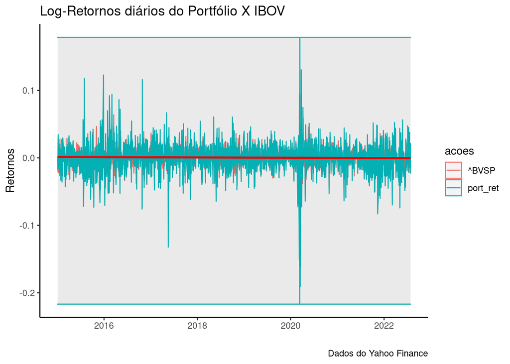

```r
ggplot(returns_port_melt_plot, aes(x=date, y= retornos, col = acoes))+
  geom_line() +
  theme_classic() +
  geom_smooth(method = "lm", col="red") +
   geom_ribbon(aes(ymin = min(retornos), ymax = max(retornos), group = acoes),
               alpha = 0.05) +
  labs(x='', y='Retornos',
title='Log-Retornos diários do Portfólio X IBOV',
caption='Dados do Yahoo Finance')
```

# Analisando as FDPs das variáveis de interesse

Fazemos inicialmente uma inspeção visual dos histogramas de alguns retornos

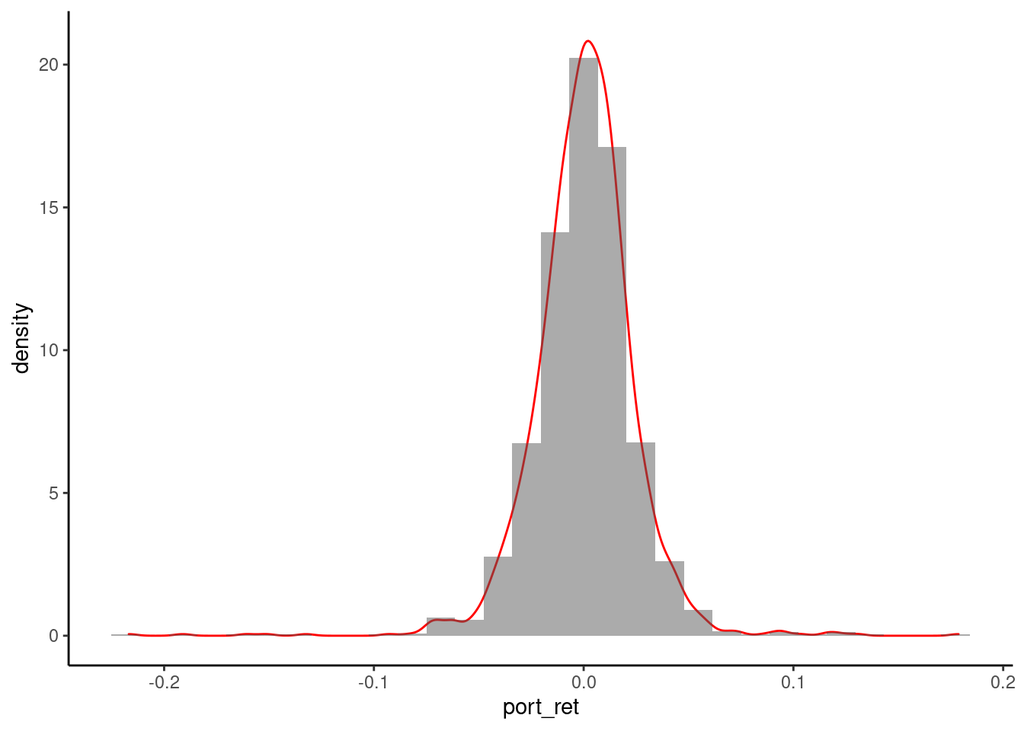

```r
ggplot(returns) +
  geom_density(aes(x=port_ret), colour = "red") +
  geom_histogram(aes(x=port_ret, y=..density..), alpha = 0.5) +
  theme_classic()
```

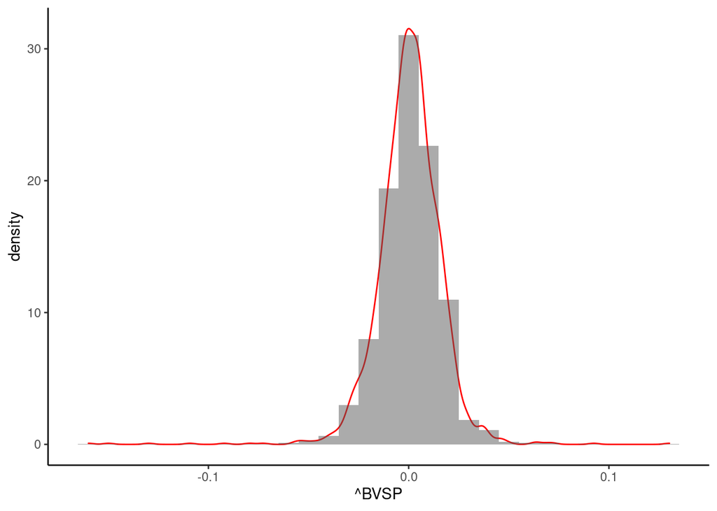

```r
ggplot(returns) +
  geom_density(aes(x=`^BVSP`), colour = "red") +
  geom_histogram(aes(x=`^BVSP`, y=..density..), alpha = 0.5) +
  theme_classic()
```

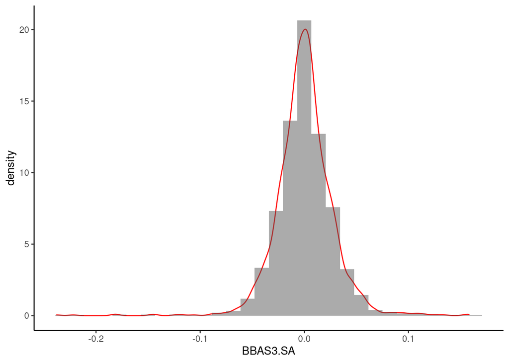

```r
ggplot(returns) +
  geom_density(aes(x=BBAS3.SA), colour = "red") +
  geom_histogram(aes(x=BBAS3.SA, y=..density..), alpha = 0.5) +
  theme_classic()
```

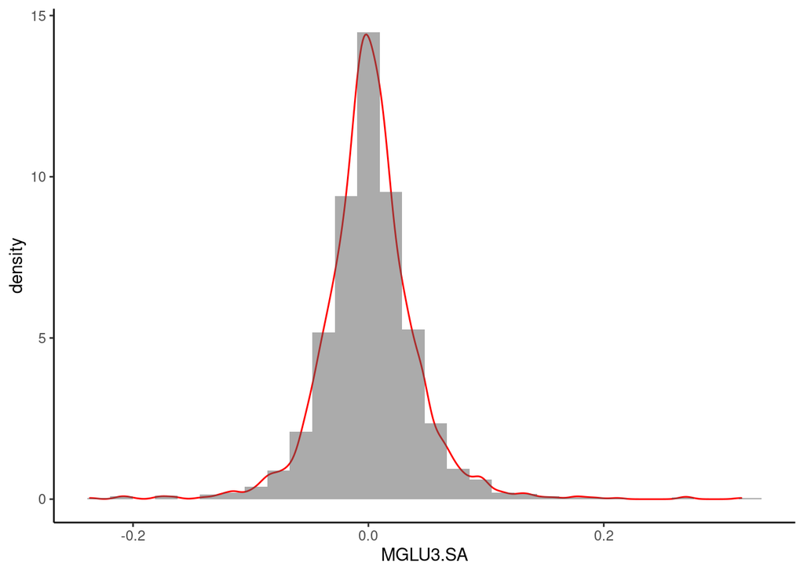

```r
ggplot(returns) +
  geom_density(aes(x=MGLU3.SA), colour = "red") +
  geom_histogram(aes(x=MGLU3.SA, y=..density..), alpha = 0.5) +
  theme_classic()
```

# Estimando o Modelo de Regressão

De modo a estimar o modelo por MQO, definindo o retorno de um ativo qualquer $R_{i}$ como a variável dependente e o índice *IBOVESPA* como a variável independente, fazemos uso da função lm() do R para realizar uma regressão linear simples. Este modelo é conhecido como *Market Model*.

$$\mathbb{E}(R_{i}) = \beta_{1} + \beta_{2} \cdot \mathbb{E}(R_{m})$$

```r
bb_market_model <- lm(BBAS3.SA ~ `^BVSP` , data = returns)
summary(bb_market_model)
```

```
##
## Call:
## lm(formula = BBAS3.SA ~ `^BVSP`, data = returns)
##
## Residuals:
##       Min        1Q    Median        3Q       Max
## -0.187994 -0.009162 -0.000679  0.008670  0.107754
##
## Coefficients:
##              Estimate Std. Error t value Pr(>|t|)
## (Intercept) -0.000299   0.000388  -0.771    0.441
## `^BVSP`      1.370393   0.023674  57.886   <2e-16 ***
## ---
## Signif. codes:  0 '***' 0.001 '**' 0.01 '*' 0.05 '.' 0.1 ' ' 1
##
## Residual standard error: 0.01679 on 1871 degrees of freedom
## Multiple R-squared:  0.6417, Adjusted R-squared:  0.6415
## F-statistic:  3351 on 1 and 1871 DF,  p-value: < 2.2e-16
```

# Diagnóstico do Modelo

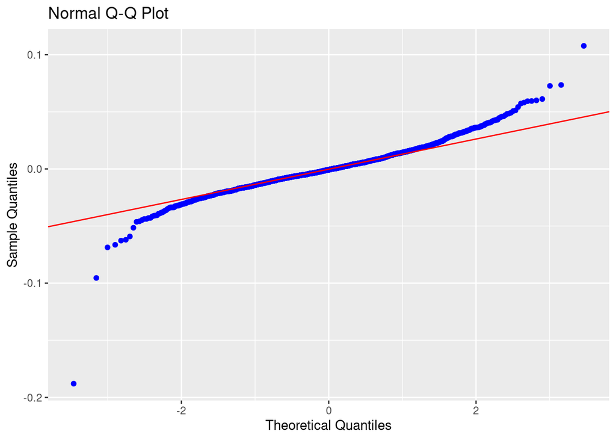

```r
ols_plot_resid_qq(bb_market_model)
```

```r
ols_test_normality(bb_market_model)
```

```
## -----------------------------------------------
##        Test             Statistic       pvalue
## -----------------------------------------------
## Shapiro-Wilk              0.9394         0.0000
## Kolmogorov-Smirnov        0.0555         0.0000
## Cramer-von Mises         604.8432        0.0000
## Anderson-Darling         12.6457         0.0000
## -----------------------------------------------
```

```r
ols_test_correlation(bb_market_model)
```

```
## [1] 0.9678642
```

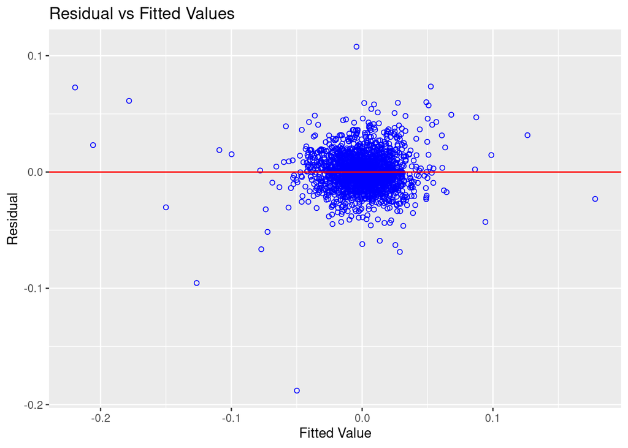

```r
ols_plot_resid_fit(bb_market_model)
```

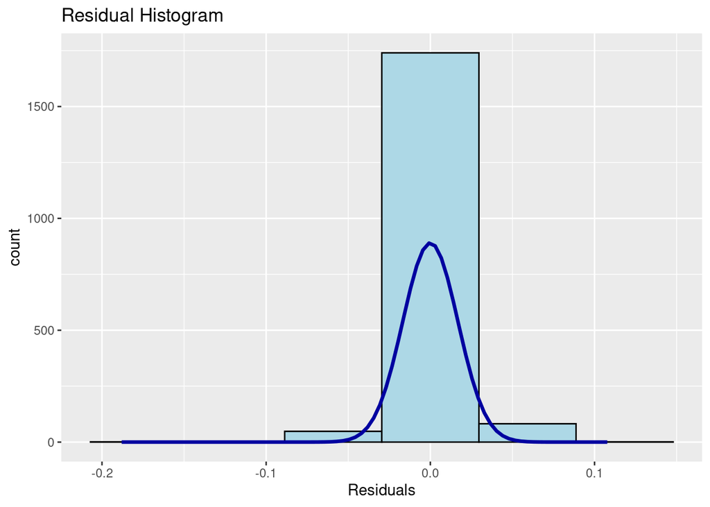

```r
ols_plot_resid_hist(bb_market_model)
```

# Testes de Homogeneidade da Variância (Homecedasticidade) e Autocorrelação

```r
lmtest::bptest(bb_market_model)
```

```
##
##  studentized Breusch-Pagan test
##
## data:  bb_market_model
## BP = 10.18, df = 1, p-value = 0.00142
```

```r
car::ncvTest(bb_market_model)
```

```
## Non-constant Variance Score Test
## Variance formula: ~ fitted.values
## Chisquare = 64.4396, Df = 1, p = 9.9537e-16
```

```r
lmtest::dwtest(bb_market_model)
```

```
##
##  Durbin-Watson test
##
## data:  bb_market_model
## DW = 2.0151, p-value = 0.629
## alternative hypothesis: true autocorrelation is greater than 0
```

# Corrigindo as Estimações para Heterocedasticidade

```r
coeftest(bb_market_model, vcov = vcovHC(bb_market_model, "HC1"))
```

```
##
## t test of coefficients:
##
##                Estimate  Std. Error t value Pr(>|t|)
## (Intercept) -0.00029902  0.00039077 -0.7652   0.4442
## `^BVSP`      1.37039341  0.04604237 29.7637   <2e-16 ***
## ---
## Signif. codes:  0 '***' 0.001 '**' 0.01 '*' 0.05 '.' 0.1 ' ' 1
```

# Plotando as observações em um Gráfico

Agora iremos plotar os dados e o modelo estimado em um gráfico.

1º plotamos o gráfico só com as observações:

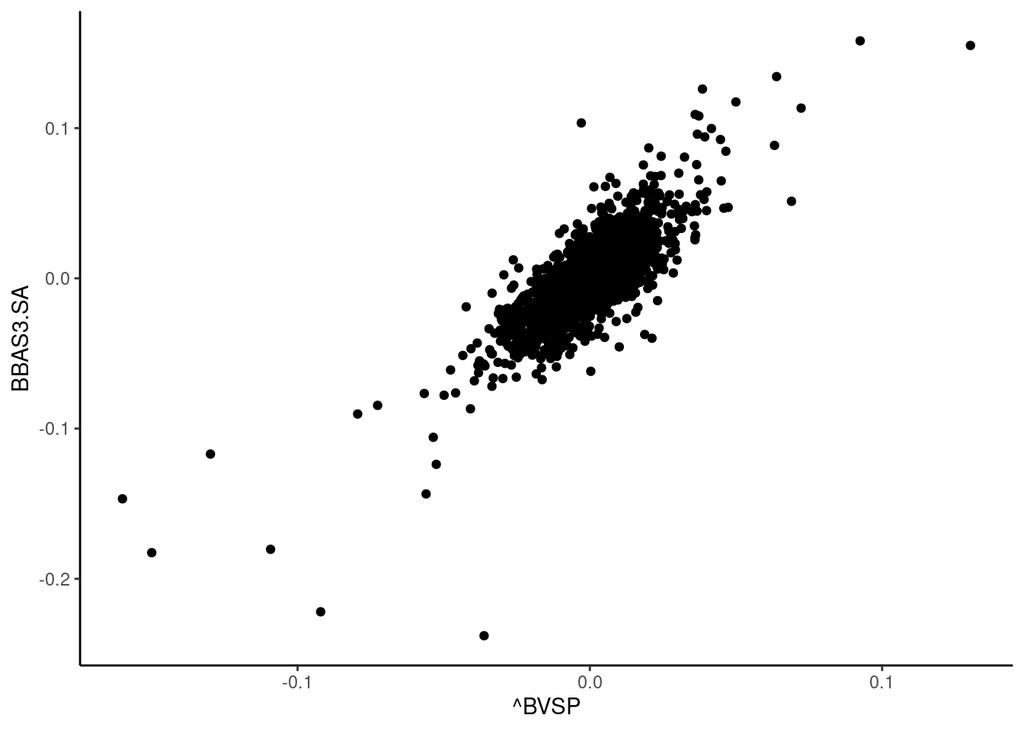

```r
data.graph = ggplot(returns, aes(x=`^BVSP`, y=BBAS3.SA))+
                     geom_point() +
                     theme_classic()
data.graph
```

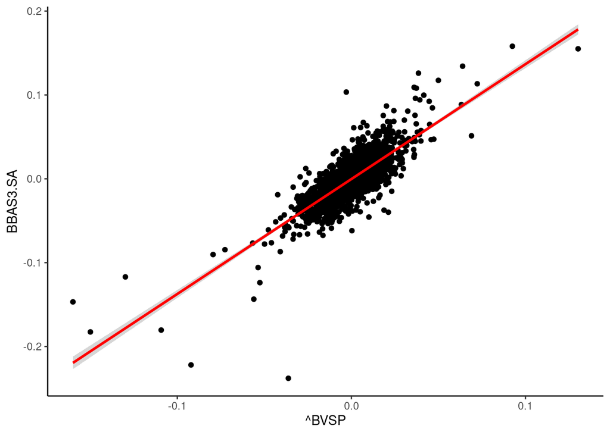

```r
data.graph = data.graph +
  geom_smooth(method="lm", col="red", level=0.95)

data.graph
```

Por fim plotamos o gráfico com a regressão linear proposta

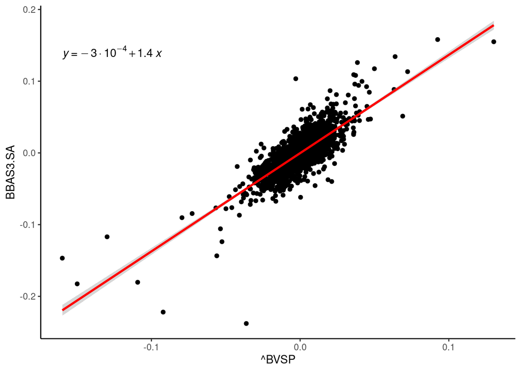

```r
data.graph <- data.graph +
  stat_regline_equation()

data.graph
```

## Forecast - Predição do Retornos Esperados do BB

Vamos tentar agora gerar a predição com o modelo proposto.

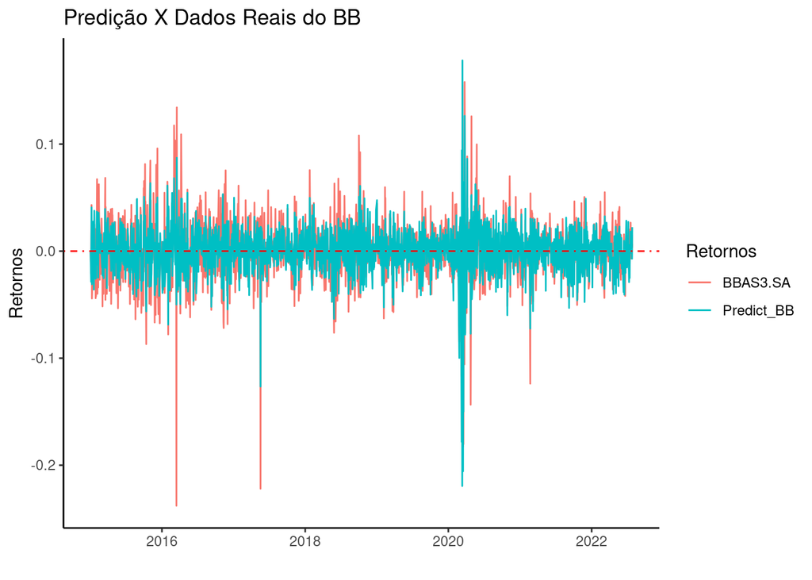

```r
real_data_bb = returns %>% select(date, BBAS3.SA)
predict_data_bb = data.frame(predict(bb_market_model))
  colnames(predict_data_bb) = c("Predict_BB")

data_bb = cbind(real_data_bb, predict_data_bb)


ggplot(data_bb, aes(x=date))+
  geom_line(aes(y = BBAS3.SA, colour = "BBAS3.SA")) +
  geom_line(aes(y = Predict_BB, colour = "Predict_BB")) +
  theme_classic() +
  geom_hline(yintercept = 0, color="red", linetype = "dotdash") +
  labs(x='', y='Retornos',
title='Predição X Dados Reais do BB',
color = "Retornos")
```